# Unit 3 Homework - Housing regression with AES data

# load packages

```r
packages <- c("AER", "ggplot2", "PerformanceAnalytics", "plyr")
sapply(packages, library, character.only = TRUE)
```

# Read in the data

```r
data("HousePrices")
df<- HousePrices
```

# Quick EDA

```r
summary(df)
```

```
     price           lotsize         bedrooms       bathrooms        stories      driveway  recreation fullbase
 Min.   : 25000   Min.   : 1650   Min.   :1.000   Min.   :1.000   Min.   :1.000   no : 77   no :449    no :355
 1st Qu.: 49125   1st Qu.: 3600   1st Qu.:2.000   1st Qu.:1.000   1st Qu.:1.000   yes:469   yes: 97    yes:191
 Median : 62000   Median : 4600   Median :3.000   Median :1.000   Median :2.000
 Mean   : 68122   Mean   : 5150   Mean   :2.965   Mean   :1.286   Mean   :1.808
 3rd Qu.: 82000   3rd Qu.: 6360   3rd Qu.:3.000   3rd Qu.:2.000   3rd Qu.:2.000
 Max.   :190000   Max.   :16200   Max.   :6.000   Max.   :4.000   Max.   :4.000
 gasheat   aircon        garage       prefer
 no :521   no :373   Min.   :0.0000   no :418
 yes: 25   yes:173   1st Qu.:0.0000   yes:128
                     Median :0.0000
                     Mean   :0.6923
                     3rd Qu.:1.0000
                     Max.   :3.0000
```

```r
str(df)
```

```
'data.frame':   546 obs. of  12 variables:
 $ price     : num  42000 38500 49500 60500 61000 66000 66000 69000 83800 88500 ...
 $ lotsize   : num  5850 4000 3060 6650 6360 4160 3880 4160 4800 5500 ...
 $ bedrooms  : num  3 2 3 3 2 3 3 3 3 3 ...
 $ bathrooms : num  1 1 1 1 1 1 2 1 1 2 ...
 $ stories   : num  2 1 1 2 1 1 2 3 1 4 ...
 $ driveway  : Factor w/ 2 levels "no","yes": 2 2 2 2 2 2 2 2 2 2 ...
 $ recreation: Factor w/ 2 levels "no","yes": 1 1 1 2 1 2 1 1 2 2 ...
 $ fullbase  : Factor w/ 2 levels "no","yes": 2 1 1 1 1 2 2 1 2 1 ...
 $ gasheat   : Factor w/ 2 levels "no","yes": 1 1 1 1 1 1 1 1 1 1 ...
 $ aircon    : Factor w/ 2 levels "no","yes": 1 1 1 1 1 2 1 1 1 2 ...
 $ garage    : num  1 0 0 0 0 0 2 0 0 1 ...
 $ prefer    : Factor w/ 2 levels "no","yes": 1 1 1 1 1 1 1 1 1 1 ...
```

```r
head(df)
```

|  | price | lotsize | bedrooms | bathrooms | stories | driveway | recreation | fullbase | gasheat | aircon | garage | prefer |
| --- | --- | --- | --- | --- | --- | --- | --- | --- | --- | --- | --- | --- |
| 1 | 42000 | 5850 | 3 | 1 | 2 | yes | no | yes | no | no | 1 | no |
| 2 | 38500 | 4000 | 2 | 1 | 1 | yes | no | no | no | no | 0 | no |
| 3 | 49500 | 3060 | 3 | 1 | 1 | yes | no | no | no | no | 0 | no |
| 4 | 60500 | 6650 | 3 | 1 | 2 | yes | yes | no | no | no | 0 | no |
| 5 | 61000 | 6360 | 2 | 1 | 1 | yes | no | no | no | no | 0 | no |
| 6 | 66000 | 4160 | 3 | 1 | 1 | yes | yes | yes | no | yes | 0 | no |

### Looks like we have a few factors that are 2 levels and not boolean. Although R will fix this automatically in the regression, lets fix that:

```r
df$driveway <- as.numeric(df$driveway =='yes')
df$recreation<- as.numeric(df$recreation =='yes')
df$fullbase <- as.numeric(df$fullbase =='yes')
df$gasheat <- as.numeric(df$gasheat =='yes')
df$aircon <- as.numeric(df$aircon == 'yes')
df$prefer <- as.numeric(df$prefer == 'yes')
```

### let’s look at some breakdowns of the data:

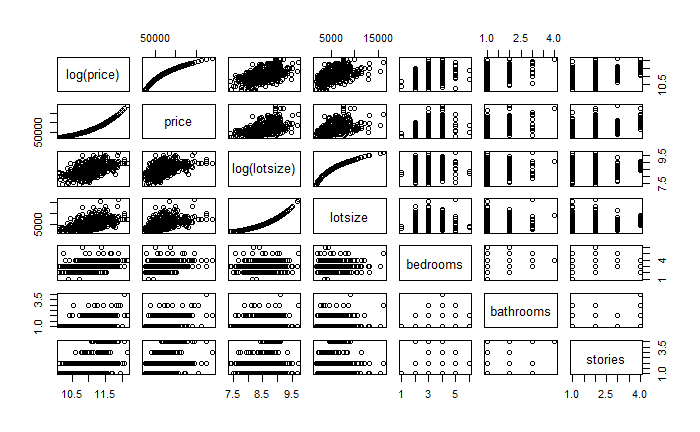

### correlations:

```r
# cor(df)
# log-base
cor(log(df$price), df$lotsize)
```

```
[1] 0.5429071
```

```r
cor(log(df$price), df$bedrooms)
```

```
[1] 0.3698846
```

```r
cor(log(df$price), df$bathrooms)
```

```
[1] 0.4846417
```

```r
cor(log(df$price), df$stories)
```

```
[1] 0.4161148
```

```r
# base-base
cor(df$price, df$lotsize)
```

```
[1] 0.5357957
```

```r
cor(df$price, df$bedrooms)
```

```
[1] 0.3664474
```

```r
cor(df$price, df$bathrooms)
```

```
[1] 0.5167193
```

```r
cor(df$price, df$stories)
```

```
[1] 0.4211902
```

```r
# log-log
cor(log(df$price), log(df$lotsize))
```

```
[1] 0.5799856
```

```r
cor(log(df$price), log(df$bedrooms))
```

```
[1] 0.3908739
```

```r
cor(log(df$price), log(df$bathrooms))
```

```
[1] 0.4893604
```

```r
cor(log(df$price), log(df$stories))
```

```
[1] 0.3833027
```

### the scatterplot matrix is interesting,let’s take a deeper look:

```
Ignoring unknown parameters: fun.y
```

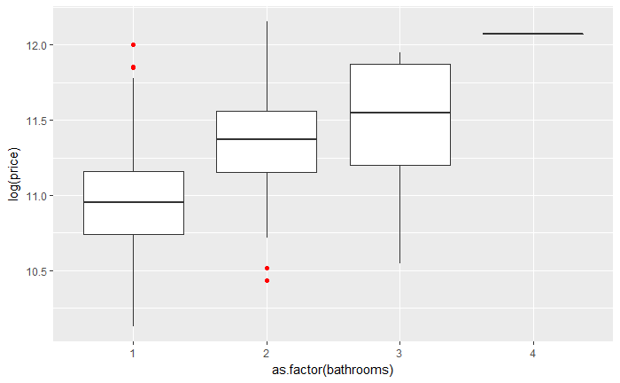

```r
ggplot(df, aes(x =as.factor(bathrooms), y = log(price)), color = bathrooms) +  geom_boxplot(outlier.colour = 'red', fun.y = mean)
```

```r
count(df, 'bedrooms')
```

| bedrooms | freq |
| --- | --- |
| 1 | 2 |
| 2 | 136 |
| 3 | 301 |
| 4 | 95 |
| 5 | 10 |
| 6 | 2 |

```r
count(df, 'bathrooms')

# there is only 1-  4 bathroom house
```

[output not shown]

# Create training and test sets of data:

```r
# doing an 80-20 split for convenience:
# create the holdout indices:
set.seed(100)
indices <- sample(1:nrow(df), size = nrow(df) *.2)
training<- df[-indices,]
test <- df[indices,]
# check to make sure that it worked (sb 0)
print(nrow(df) - (nrow(training) + nrow(test)))
```

```
[1] 0
```

# Baseline naive regression:

```r
# the goal is to beat this naive forecast:
naive_lm <- lm(price~ lotsize, data = training)
```

### Naive summary:

```r
summary(naive_lm)
```

```
Call:
lm(formula = price ~ lotsize, data = training)

Residuals:
   Min     1Q Median     3Q    Max
-69092 -14171  -2416   9925 107282

Coefficients:
             Estimate Std. Error t value Pr(>|t|)
(Intercept) 3.386e+04  2.665e+03   12.71   <2e-16 ***
lotsize     6.585e+00  4.735e-01   13.91   <2e-16 ***
---
Signif. codes:  0 ‘***’ 0.001 ‘**’ 0.01 ‘*’ 0.05 ‘.’ 0.1 ‘ ’ 1

Residual standard error: 21730 on 435 degrees of freedom
Multiple R-squared:  0.3078,    Adjusted R-squared:  0.3062
F-statistic: 193.4 on 1 and 435 DF,  p-value: < 2.2e-16
```

### Naive ANOVA

```r
Anova(naive_lm)
```

```
Anova Table (Type II tests)

Response: price
              Sum Sq  Df F value    Pr(>F)
lotsize   9.1323e+10   1  193.39 < 2.2e-16 ***
Residuals 2.0541e+11 435
---
Signif. codes:  0 ‘***’ 0.001 ‘**’ 0.01 ‘*’ 0.05 ‘.’ 0.1 ‘ ’ 1
```

It does appear that the lot size variable is significant

### Diagnostics:

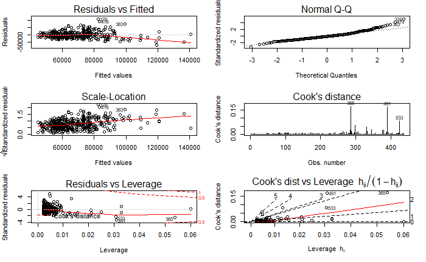

```r
par(mfrow = c(3,2))
plot(naive_lm, which = 1:6)
par(mfrow = c(1,1))
```

### based on the residuals of this model there are a few things to note:

```
1.) There appears to be some heteroskedasticity in the residuals, this may be due to sparsity in the data, it may also be because we have not transformed any variables yet
2.) This also means that the residuals are not normally distributed (potentially based on QQplot)
3.) WE do seem to have a few highly influential outliers; although maybe not as much of a concern given that we are training on 437 observations
```

### Naive accuracy:

```r
naive_pred<- predict(naive_lm,  test)
MAPE <- mean(abs(naive_pred / test$price -1))
MAPE
```

```
[1] 0.3015798
```

### Now that we have established a baseline error of 30% to beat, let’s try to beat it:

### Model 1: add bathrooms, bedrooms, stories

```r
lm<- lm(log(price)~ lotsize + bathrooms + bedrooms + stories, data = training)
summary(lm)
```

```
Call:
lm(formula = log(price) ~ lotsize + bathrooms + bedrooms + stories,
    data = training)

Residuals:
     Min       1Q   Median       3Q      Max
-0.75701 -0.17070  0.01198  0.16465  0.63276

Coefficients:
             Estimate Std. Error t value Pr(>|t|)
(Intercept) 1.006e+01  5.418e-02 185.685  < 2e-16 ***
lotsize     7.744e-05  5.577e-06  13.886  < 2e-16 ***
bathrooms   1.977e-01  2.748e-02   7.196 2.77e-12 ***
bedrooms    5.210e-02  1.828e-02   2.850  0.00459 **
stories     1.061e-01  1.555e-02   6.823 3.03e-11 ***
---
Signif. codes:  0 ‘***’ 0.001 ‘**’ 0.01 ‘*’ 0.05 ‘.’ 0.1 ‘ ’ 1

Residual standard error: 0.2491 on 432 degrees of freedom
Multiple R-squared:  0.5378,    Adjusted R-squared:  0.5335
F-statistic: 125.7 on 4 and 432 DF,  p-value: < 2.2e-16
```

It looks like the adjusted r-squared went up a good bit in this model and that all of the variables appear to be significatnt. We also appear to be getting an overall significant result besed on the overall F-test.

We also need to check for collinearity:

```r
vif(lm)
```

```
  lotsize bathrooms  bedrooms   stories
 1.055422  1.264454  1.315752  1.248433
```

This is actually a good sign. It appears that there is very little collinearity between the variables (this was also evidenced in the previous observations of correlations in the scatterplot matrix)

### Diagnostics:

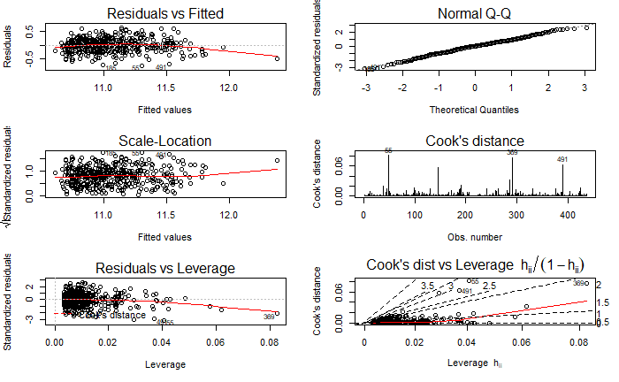

```r
par(mfrow = c(3,2))
plot(lm, which = 1:6)
par(mfrow = c(1,1))
```

This looks alot better, the redisuals appear to be normally distributed and they do appear to be homoskedastic (despite the line looking odd - this is just because of the lack of observations, we still maintain residuals within the range). There do appear to be some leverage, points, but we can address those later if we really need to tunr the model. The Cook’s D is still very low overall.

Test the accuracy:

```r
pred_1 <- predict(lm, test)
MAPE <- mean(abs(pred_1 / log(test$price) -1))
MAPE
```

```
[1] 0.0206497
```

This model produces an error rate of 2.0%, pretty impressive improvement with just a few additional variables

### Model 2 : transform lotsize

```r
training_2<- training
training_2$lotsize <- log(training_2$lotsize)
test_2<- training
test_2$lotsize <- log(test_2$lotsize)
lm_2<- lm(log(price)~ lotsize + bathrooms + bedrooms + stories, data = training_2)
summary(lm_2)
```

```
Call:
lm(formula = log(price) ~ lotsize + bathrooms + bedrooms + stories,
    data = training_2)

Residuals:
     Min       1Q   Median       3Q      Max
-0.74373 -0.15996  0.01066  0.15899  0.59323

Coefficients:
            Estimate Std. Error t value Pr(>|t|)
(Intercept)  6.59919    0.24596  26.830  < 2e-16 ***
lotsize      0.45748    0.02963  15.439  < 2e-16 ***
bathrooms    0.18959    0.02657   7.136 4.08e-12 ***
bedrooms     0.05418    0.01763   3.073  0.00225 **
stories      0.10067    0.01501   6.705 6.30e-11 ***
---
Signif. codes:  0 ‘***’ 0.001 ‘**’ 0.01 ‘*’ 0.05 ‘.’ 0.1 ‘ ’ 1

Residual standard error: 0.2405 on 432 degrees of freedom
Multiple R-squared:  0.5692,    Adjusted R-squared:  0.5652
F-statistic: 142.7 on 4 and 432 DF,  p-value: < 2.2e-16
```

The adj r-squared went up slightly with this model, which could be a good sign given that we did not add any additional variables

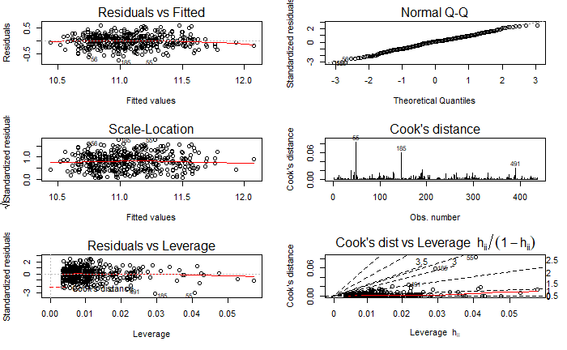

```r
par(mfrow = c(3,2))
plot(lm_2, which = 1:6)
par(mfrow = c(1,1))
```

This model looks even better

Test the accuracy:

```r
pred_2 <- predict(lm_2, test_2)
MAPE <- mean(abs(pred_2 / log(test_2$price) -1))
MAPE
```

```
[1] 0.01697214
```

### Model 3 : add the log of the remaining variables

```r
training_3<- training
training_3$lotsize <- log(training_3$lotsize)
training_3$bathrooms <- log(training_3$bathrooms)
training_3$bedrooms <- log(training_3$bedrooms)
training_3$stories <- log(training_3$stories)
test_3<- test
test_3$lotsize <- log(test_3$lotsize)
test_3$bathrooms <- log(test_3$bathrooms)
test_3$bedrooms <- log(test_3$bedrooms)
test_3$stories <- log(test_3$stories)
lm_3<- lm(log(price)~ lotsize + bathrooms + bedrooms + stories, data = training_3)
summary(lm_3)
```

```
Call:
lm(formula = log(price) ~ lotsize + bathrooms + bedrooms + stories,
    data = training_3)

Residuals:
     Min       1Q   Median       3Q      Max
-0.73590 -0.16845  0.02181  0.15794  0.59565

Coefficients:
            Estimate Std. Error t value Pr(>|t|)
(Intercept)  6.80090    0.25013  27.190  < 2e-16 ***
lotsize      0.46514    0.02969  15.665  < 2e-16 ***
bathrooms    0.30301    0.03994   7.586 2.04e-13 ***
bedrooms     0.16861    0.05442   3.098  0.00207 **
stories      0.17112    0.02996   5.712 2.08e-08 ***
---
Signif. codes:  0 ‘***’ 0.001 ‘**’ 0.01 ‘*’ 0.05 ‘.’ 0.1 ‘ ’ 1

Residual standard error: 0.2403 on 432 degrees of freedom
Multiple R-squared:  0.5701,    Adjusted R-squared:  0.5661
F-statistic: 143.2 on 4 and 432 DF,  p-value: < 2.2e-16
```

There is very little improvmement in the asj r^2 here. This probably means that we may not be adding that much more explaianbility to the model. We also notice that the coefficients for bedrooms and stories are very small for each percentage change in the respective variable

```r
pred_3 <- predict(lm_3, test_3)
MAPE <- mean(abs(pred_3 / log(test_3$price) -1))
MAPE
```

```
[1] 0.0204332
```

This model was only slightly better than the original (2% error). However, the previous model actually beat this model’s accuracy score.

### ANOVA tests:

```r
anova( lm_2, lm_3)
```

```
Analysis of Variance Table

Model 1: log(price) ~ lotsize + bathrooms + bedrooms + stories
Model 2: log(price) ~ lotsize + bathrooms + bedrooms + stories
  Res.Df    RSS Df Sum of Sq F Pr(>F)
1    432 24.992
2    432 24.939  0  0.052916
```

### Conclusion

While we didn’t necessarily evaluate the models all solely based on the the ANOVA approach, we did take more of a data mining approach of looking at accuracy, which is what tends to count in the end assuming all assumptions were met. In this case, we met all of the regression assumptions nad produced a model that was more accurate. Going forward, we might consider trying additional regressions based on machine learning classification, such as Support vector regression, artificial neural networks, or boosting